# DWEI5_Aula07_Flask-ControllersFlaskAdmin

Instituto Federal de São Paulo (IFSP)  
[Campus Bragança Paulista/SP](https://bra.ifsp.edu.br)  
**Análise e Desenvolvimento de Sistemas (ADS)**  
**5o. módulo**  
**Profa. Ana Paula Müller Giancoli**  
paulagiancoli@ifsp.edu.br

## AULA 07 - CONTROLLERS E FLASK-ADMIN

### Agenda

- Adequação do Projeto para uso de Controllers
- Adequação do Projeto para uso do Flask-Admin
- Criando o Controller do Usuário
- Modificando os Models
- Criando o Admin
- Perguntas

### 1. Adequando o Projeto para utilizar os Controllers e Área Administrativa do Flask (Flask-Admin)

- Os **controllers** são responsáveis por realizar a comunicação entre as requisições das views (rotas e templates) e o banco de dados (models).

### 1.1. Localize o arquivo Usuario.py na pasta models

- Adicionando os métodos para gerar, atualizar e verificar a senha dos usuários.
- Os demais métodos foram inseridos para serem configurados e utilizados posteriormente.

```
# -*- coding: utf-8 -*-
from flask_sqlalchemy import SQLAlchemy

# Adicionado para permitir relacionamento entre as classes Usuario e Perfil
from sqlalchemy.orm import relationship                                       <--- Adicione

from config import app_config, app_active
from models.Perfil import Perfil                                              <--- Adicione

# Biblioteca adicionada para criptografia de senha
from passlib.hash import pbkdf2_sha256


config = app_config[app_active]
db = SQLAlchemy(config.APP)


class Usuario(db.Model):
    id=db.Column(db.Integer,primary_key=True)
    username=db.Column(db.String(40),unique=True,nullable=False)
    email=db.Column(db.String(120),unique=True,nullable=False)
    password=db.Column(db.String(80),nullable=False)
    date_created=db.Column(db.DateTime(6),default=db.func.current_timestamp(),nullable=False)
    last_update=db.Column(db.DateTime(6),onupdate=db.func.current_timestamp(),nullable=True)
    recovery_code=db.Column(db.String(100),nullable=True)
    active=db.Column(db.Boolean(),default=1,nullable=False)
    relacao=db.Column(db.Integer,db.ForeignKey(Perfil.id),nullable=False)       <--- Adicione


# <--- Adicione daqui pra frente ------->
    # Adicionado para permitir a relação entre a classe Usuário e a classe Perfil.
    perfil = relationship(Perfil)

    # Adicionado para exibir da forma que é definida na chamada do objeto da classe.
    # É a forma que será exibido no campo de relacionamento.
    def __repr__(self):
        return '%s - %s' % (self.id, self.username)


    # Métodos adicionados para configuração posterior
    def get_usuario_by_email(self):
        # Método para validar se usuário existe ou não
        return ' '

    def get_usuario_by_id(self):
        # Método para listar dados do usuário perfil
        return ' '

    def update_usuario(self, obj):
        # Método para atualizar o usuário
        return ' '

    # Adicionando os métodos para criptografia de senha
    # Metodo de conversão de senha de string para string criptografada
    def hash_password(self, password):
        try:
            return pbkdf2_sha256.hash(password)
        except Exception as e:
            print("Erro ao tentar criptografar a senha %s" % e)

    # Método para atualizar senha
    def set_password(self, password):
        self.password = pbkdf2_sha256.hash(password)

    # Método para verificar se a senha informada é igual a que está no banco de dados
    def verify_password(self, password_no_hash, password_database):
        try:
            return pbkdf2_sha256.verify(password_no_hash, password_database)
        except ValueError:
            return False
```

### 1.2. Localize o arquivo Usuario.py na pasta controllers

- Crie o código abaixo.

```
from models.Usuario import Usuario

class UsuarioController():
    # Método construtor da classe UsuarioController.
    def __init__(self):
        # Inicializa uma instância de Usuario().
        self.usuario_model = Usuario()

    # Método que será utilizado para ligar a rota de login com a Model de Usuário
    def login(self, email, password):
        # Recebe os dados de e-mail e salva no atributo da Model de Usuário.
        self.usuario_model.email = email

        # Verifica se o usuário existe no banco de dados e atribui a resultado.
        resultado = self.usuario_model.get_usuario_by_email()

        # Caso o usuário exista o resultado não será None
        if resultado is not None:
            # Verifica se a senha que o usuário enviou, agora convertido em hash, é igual a senha que foi pega no banco de dados para esse usuário.
            res = self.usuario_model.verify_password(password, resultado.password)

            # Se forem a mesma, retorna True.
            if res:
                return resultado
            else:
                return {}
        return {}

        def recuperar(email):
            # Criado somente para exemplificar a recuperação de senha por email.
            # Rota do app.py: @app.route('/recuperar-senha/', methods=['POST'])
            return ''
```

### 1.3. Localize o arquivo app.py dentro da pasta projeto

- Faça as adequações.

```
#  É importado da biblioteca flask, a classe Flask.
from flask import Flask, request, redirect, render_template    <--- Adicione redirect, render_template

# É importado do arquivo config.py, as variáveis app_config, app_active que app_config: possui as configurações e o tipo de ambiente a ser utilizado (Desenvolvimento, Teste ou Producao). E app_active: possui as configurações de qual ambiente está sendo utilizado por meio da variável de ambiente FLASK_ENV.
from config import app_config, app_active

# Importando a biblioteca de administração para utilizar o método start-views
from admin.Admin import start_views                            <--- Adicione

# Adicionando o controller de Usuário para efetuar a comunicação entre a view e a model.
from controllers.Usuario import UsuarioController              <--- Adicione

# A variável config recebe a atribuição do ambiente ativo.
config = app_config[app_active]

# Adicionado para criar a migracao do banco de dados
from flask_sqlalchemy import SQLAlchemy

# Dentro do método create_app(), faça a adequação:
# Método create_app que recebe como argumento com todas as configurações da aplicação.
def create_app(config_name):

    # A variável app recebe uma instância de Flask, passando a configuração da localização dos templates. Pode
    # receber diversas configurações.
    app = Flask(__name__, template_folder='templates')

    # O atributo secret_key da aplicação app, recebe a configuração da chave secreta do arquivo config.py, por meio da variável config e atributo SECRET.
    app.secret_key = config.SECRET

    # Efetua o carregamento do arquivo config.py
    app.config.from_object(app_config[config_name])
    app.config.from_pyfile('config.py')

    # Adicionado para migrar o banco de dados
    app.config['SQLALCHEMY_DATABASE_URI'] = config.SQLALCHEMY_DATABASE_URI

    # Configuração indicando que as modificações do banco de dados poderão ser exclusivamente pela aplicação.
    # Se True, permite outras formas.
    app.config['SQLALCHEMY_TRACK_MODIFICATIONS'] = config.SQLALCHEMY_TRACK_MODIFICATIONS

    # A variável db receberá a atribuição de uma instância do SQLAlchemy passando a aplicação app criada.
    db = SQLAlchemy(config.APP)

    # Adicionado a inicialização das visualizações das views Admin. Ativa a área admin do Flask.
    # A Admin será criada dentro do arquivo admin/Admin.py
    start_views(app,db)                                             <--- Adicione

    # Inicializando o banco de dados para a aplicação.
    db.init_app(app)


# <--- Adequar daqui pra frente ------->
    # Primeira rota a ser criada. A rota principal root.
    # Quando se cria duas ou mais rotas seguidas antes do método, isso indica ao navegador que qualquer uma delas acessa o método a seguir. Neste exemplo tanto http://localhost:8000/ e http://localhost:8000/login/ acessam o médtodo index(). Que retorna uma string.
    @app.route('/')
    @app.route('/login/')
    def index():
        return '<h1>Meu Primeiro APP Flask!</h1>'

    # Rota adicionada para verificar o login do Usuário por meio do controllers: UsuarioController()
    @app.route('/login/', methods=['POST'])
    def login_post():
        usuario = UsuarioController()
        email = request.form['email']
        password = request.form['password']
        resultado = usuario.login(email, password)
        if resultado:
            return redirect('/admin')
        else:
            return render_template('login.html', data={'status': 401, 'msg': 'Dados de usuário incorretos', 'type': None})

    # Rota adicionada para recuperação de senha
    @app.route('/recuperar-senha/')
    def recuperar_senha():
        return '<h1>Aqui entrará a tela de recuperar senha. </h1>'

    # Rota adicionada para recuperação de senha por meio do método POST.
    @app.route('/recuperar-senha/', methods=['POST'])
    def enviar_recuperar_senha():
        # Instância do Usuario Controller atribuída a variável usuario.
        usuario = UsuarioController()
        resultado = usuario.recuperar(request.form['email'])
        # Se o resultado for preenchido, executa o email de recuperação com status 200 de sucesso.
        if resultado:
            return render_template('recuperar.html', data={'status': 200, 'msg': 'E-mail de recuperação enviado com sucesso'})
        else:
            # Se o resultado for vazio, executa o email de recuperação com status 200 de sucesso.
            return render_template('recuperar.html', data={'status': 401, 'msg': 'Erro ao enviar e-mail de recuperação'})

    # Retorno do método create_app(). Retorna a instância do app criada.
    return app
```

### 1.4. Localize o arquivo Admin.py dentro da pasta admin

- Crie o código abaixo.

```
# -*- coding: utf-8 -*-
# from flask_admin import Admin: Ela possui vários recursos para criação
# de views customizadas para nossa aplicação
from flask_admin import Admin

# Componente dentro do flask_admin para ativar as views em nossa aplicação, baseadas em nossas models.
from flask_admin.contrib.sqla import ModelView
from models.Perfil import Perfil
from models.Usuario import Usuario
from models.Area import Area
from models.Modulo import Modulo
from models.Componente import Componente


def start_views(app, db):
    # Utilização do bootstrap4 por meio do construtor do Admin.
    admin = Admin(app, name='Componentes Curriculares', template_mode='bootstrap4')
    # Método que é utilizado para criar uma view em nossa aplicação Admin.
    # ModelView: é um recurso do flask_admin que permite a criação Admin, as telas do administrador baseadas na estrutura das models.
    # category é utilizado para agrupar os itens de menus.
    admin.add_view(ModelView(Perfil, db.session, "Perfis Acesso", category= "Configurações"))
    admin.add_view(ModelView(Usuario, db.session, "Usuários", category="Usuários"))
    admin.add_view(ModelView(Area, db.session, "Áreas", category="Configurações"))
    admin.add_view(ModelView(Modulo, db.session, "Módulos", category="Configurações"))
    admin.add_view(ModelView(Componente, db.session, "Componentes", category="Componentes"))
```

### 1.5. Localize o arquivo Area.py na pasta models

- Faça as adequações.

```
# -*- coding: utf-8 -*-
from flask_sqlalchemy import SQLAlchemy

from config import app_active, app_config

config = app_config[app_active]
db = SQLAlchemy(config.APP)


class Area(db.Model):
    id=db.Column(db.Integer,primary_key=True)
    area=db.Column(db.String(10),unique=True,nullable=False)
    descricao=db.Column(db.Text(),nullable=False)

# <----- Adicione daqui pra frente ------>
    # Adicionado para exibir da forma que é definida na chamada do objeto da classe.
    # É a forma que será exibido no campo de relacionamento.
    def __repr__(self):
        return self.area
```

### 1.6. Localize o arquivo Modulo.py na pasta models

- Faça as adequações.

```
# -*- coding: utf-8 -*-
from flask_sqlalchemy import SQLAlchemy
from config import app_active, app_config

config = app_config[app_active]
db = SQLAlchemy(config.APP)


class Modulo(db.Model):
    id=db.Column(db.Integer,primary_key=True)
    modulo=db.Column(db.String(10),unique=True,nullable=False)
    descricao=db.Column(db.Text(),nullable=False)


# <----- Adicione daqui pra frente ------>
    # Adicionado para exibir da forma que é definida na chamada do objeto da classe.
    # É a forma que será exibido no campo de relacionamento.
    def __repr__(self):
        return self.modulo
```

### 1.7. Localize o arquivo Perfil.py na pasta models

- Faça as adequações.

```
# -*- coding: utf-8 -*-
from flask_sqlalchemy import SQLAlchemy
from config import app_active, app_config

config = app_config[app_active]
db = SQLAlchemy(config.APP)


class Perfil(db.Model):
    id=db.Column(db.Integer,primary_key=True)
    perfil=db.Column(db.String(40),unique=True,nullable=False)


# <----- Adicione daqui pra frente ------>
    # Adicionado para exibir da forma que é definida na chamada do objeto da classe.
    # É a forma que será exibido no campo de relacionamento.
    def __repr__(self):
        return self.perfil
```

### 1.8. Localize o arquivo Componente.py na pasta models

- Faça as adequações.

```
from flask_sqlalchemy import SQLAlchemy
from config import app_active, app_config

# Adicionado para permitir relacionamento entre as classes. O campo criado exibirá as informações do relacionamento.
from sqlalchemy.orm import relationship                                   <--- Adicione

from models.Usuario import Usuario
from models.Modulo import Modulo
from models.Area import Area

config = app_config[app_active]
db = SQLAlchemy(config.APP)


class Componente(db.Model):
    id=db.Column(db.Integer,primary_key=True)
    sigla=db.Column(db.String(10),unique=True,nullable=False)
    descricao=db.Column(db.Text(),nullable=False)
    qtdeaulas=db.Column(db.Integer)
    date_created=db.Column(db.DateTime(6),default=db.func.current_timestamp(),nullable=False)
    last_update=db.Column(db.DateTime(6),onupdate=db.func.current_timestamp(),nullable=False)
    status=db.Column(db.Boolean(),default=1,nullable=True)
    user_created=db.Column(db.Integer,db.ForeignKey(Usuario.id),nullable=False)
    areaid=db.Column(db.Integer,db.ForeignKey(Area.id),nullable=False)
    moduloid=db.Column(db.Integer,db.ForeignKey(Modulo.id),nullable=False)


# <----- Adicione daqui pra frente ------>

    # Método que criará um campo no formulário de criação e edição para representar
    # o elemento que faz relacionamento com aquela tabela.
    usuario=relationship(Usuario)
    area=relationship(Area)
    modulo=relationship(Modulo)


    # Adicionado para exibir da forma que é definida na chamada do objeto da classe.
    # É a forma que será exibido no campo de relacionamento.
    def __repr__(self):
        return '%s - %s' % (self.id, self.sigla)
```

### Para testar

- Ative o ambiente virtual, digite: **source venv/bin/activate**, para o SO Windows, consulte as aulas anteriores.
- Não é necessário instalar nada, uma vez que já foi feita a instalação na aula anterior.
- Defina a **variável de ambiente FLASK_ENV=development**, indicando que estamos executando no ambiente de desenvolvimento.
- Execute **python run.py** de dentro da pasta **projeto**.
- **Observação**: No caso da minha máquina tenho 2 versões de python instaladas, uma versão 2.xx e outra 3.xx. Como quero usar a mais nova e atual, no lugar do comando python, utilizo python3. Verifique se é o caso de vocês.

### No navegador

- Digite http://localhost:8000/admin/.
- Algo parecido com:

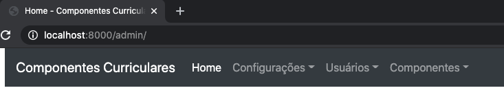

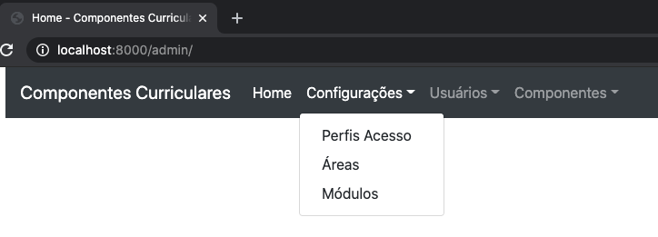

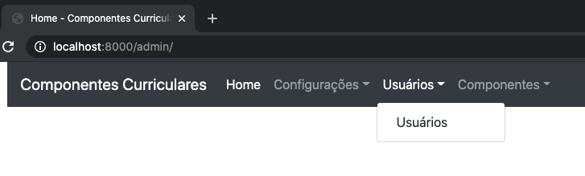

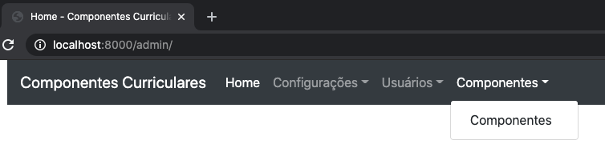

### ATENÇÃO

- **Lembre-se de encerrar o servidor ao final de cada aula**.
- **Lembre-se também, de desativar o ambiente virtual**.

### Referências

- Esta aula foi elaborada a partir do conteúdo disponibilizado em cada um dos links indicados no próprio texto.

### Perguntas

- Esclareça suas eventuais dúvidas durante as aulas.
- Ou pelo *E-mail*: paulagiancoli@ifsp.edu.br.
- Ou acesse [Github Ana Giancoli](https://anagiancoli.github.io) e solicite atendimento para o componente curricular.

*ADS - HTML5, CSS3, JS, FLASK - 5o. módulo*.  
Modelo e formato elaborado por profa. Ana Paula Müller Giancoli - BSD 2-Clause License. - Fevereiro.2021.